# Programming Data Science Report

Philipp Peter, Laurenz Harnischmacher, Nico Lindert

24 Mai 2019

# 1 Introduction

This project report is about the webshop of the company ebuy. It is based on two data sources covering the clickstream and the orders of the webshop. Additionally, the company provided us with data of an experiment on recommender systems. From this data, the goal is to find interesting correlations and infer useful predictions. To realize this goal, the data is prepared. First, the data import is described alongside basic information on the data. In this step, the data is also cleaned for further analysis (Chapter Data Preparation). Next, the data is summarized and visualized to get an impression on how the data looks like and what could be done with the data (Chapters Visualisation and Summary Statistics). After that, the prediction models are presented (Chapter Prediction). One based on the clickstream and one based in the orders. Finally, the experiment data is evaluated to find the best recommender system (Chapter Experiment).

# 2 Data Preparation

This part is rather technical and focuses on showing how the data for analysis is generated from the raw data. You may skip this part and continue with the part on Basic Data Description.

## 2.1 Data Import

Before any visualization or even analysis can take place, the data has to be imported, cleaned and prepared. The import includes the extraction of the zip archives and reading in the data. In the read in process, the different candidates for NULL values are all transformed to a representation of missing data. This includes empty cells, question marks, NULL fields, NA fields and Nan fields. Furthermore, the headers are matched with the data from an external file.

Initially the data consists of 215 in the clickstream data and 121415 rows in the first dataset. In an additional dataset there are another 42949 rows. Those two are merged in the next step.  
In the order dataset, there are 232 columns and 3465 observations.

## 2.2 Basic Data Description

Starting off with the clickstream data, it ranges from 2000-04-14 to 2000-04-30. It consists of all individual requests made by people accessing the webshop. So, it contains basic information on the request, meaning which site was requested, when it was requested and some technical information on the request. Apart from that, each observation also contains the session information. That means that there exists a portion of requests that belong to one session of a customer. The session variables save the information where the first request was made. Apart from this metadata, the rows also contain the level the customer currently visits. Whenever a product is visited, the observation in clickstream contains the information on that product, too.  
Unfortunately, the order data covers a different timeframe than the clickstream data. Its time range is from 2000-01-28 to 2000-03-31. Apart from the time, order data has a similar structure. Each row is an item contained in an order. This means that it has unique metadata, such as an identifier and which product is selected with which amount. On top of that, there is shared metadata for order items that are bought together in one shopping tour. For the products, similar metadata is given as in the clickstream table. Apart from the data that is directly related to the order, there is also customer related data which describes properties of the customer. For example, there is a column containing the gender of the customer and whether he/she owns a car. Unfortunately, only a fraction of the observation had a good cover on answered customer questions. This made the customer question unsuitable for prediction and statistical analysis.

## 2.3 Data Cleaning

Getting to *data manipulation*, a few things within the datasets had to be fixed.

1. Empty rows/observations and columns/features are removed
2. Column names included spaces that become problematic in later analysis. They are simply replaced by underscores.
3. All semicolons within cells are simply erased
4. Besides, backslashes within cells are erased as well.

In addition to the cleaning tasks, additional columns were created. One particularly important one is the column LeadsToBuy, that is a boolean column being true whenever a clickstream interaction leads to the buying of products. This is realized by comparing the requested site with a special one that only occurs after a checkout has been completed.

To be able to look at the aggregated data across sessions, a dataset consisting of the sessions is created. It contains the session duration, the visited products, whether a session leads to the purchase of a product and a list of all visited products.

# 3 Visualisation

On a first look, the data provides the following information:

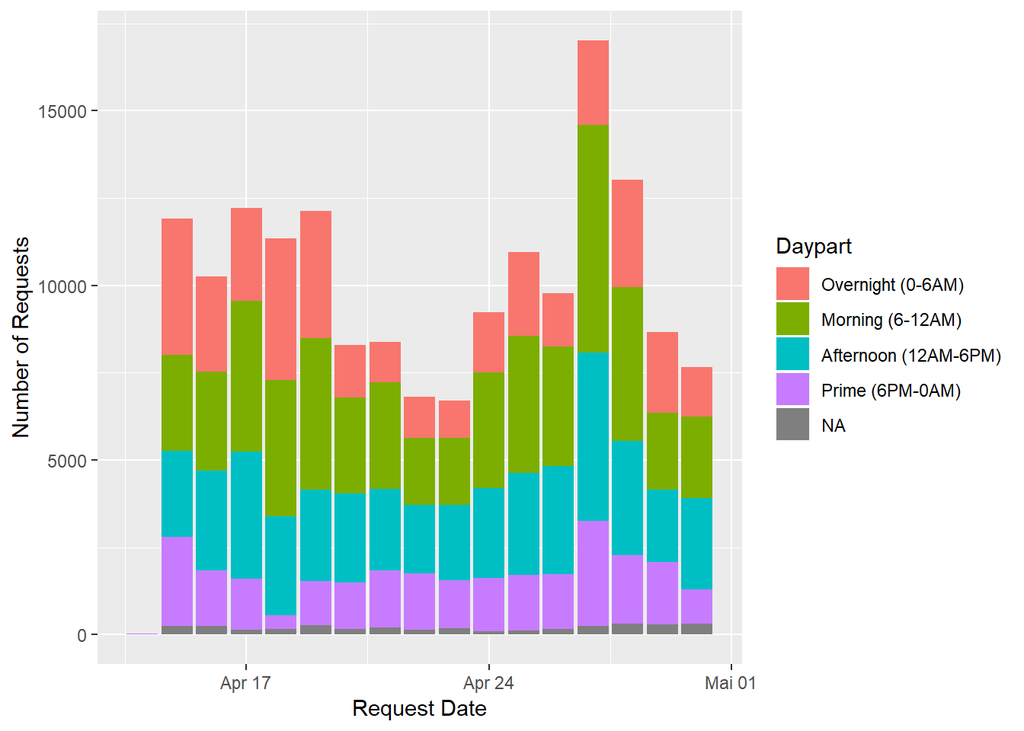

Besides one pike at the end of April the distribution of clicks is even over the time range of the clickstream dataset. In terms of daypart overnight, morning and afternoon seems to have approximately the same number of clicks over time.

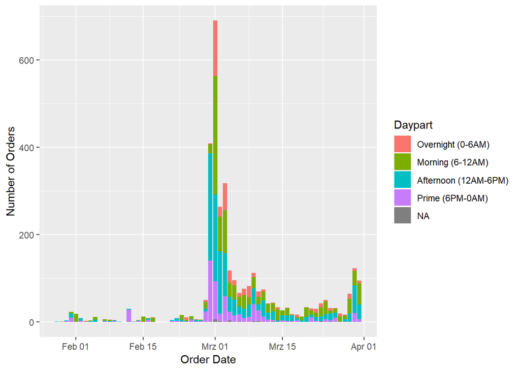

What can be observed is that most of the orders were placed at March 1, namely 690. 1946 or 56.2% of all orders have been placed in the week of February 28.  
Further, interestingly the amount of orders of March 1 placed overnight or in the morning is quite high. It could be assumed that there was a special time limited offer in the early hours of March 1.  
Overall, only 323 customers specified their gender as “male” and 1584 as “female”. However, men seem to spend more money on average as the boxplot indicates.

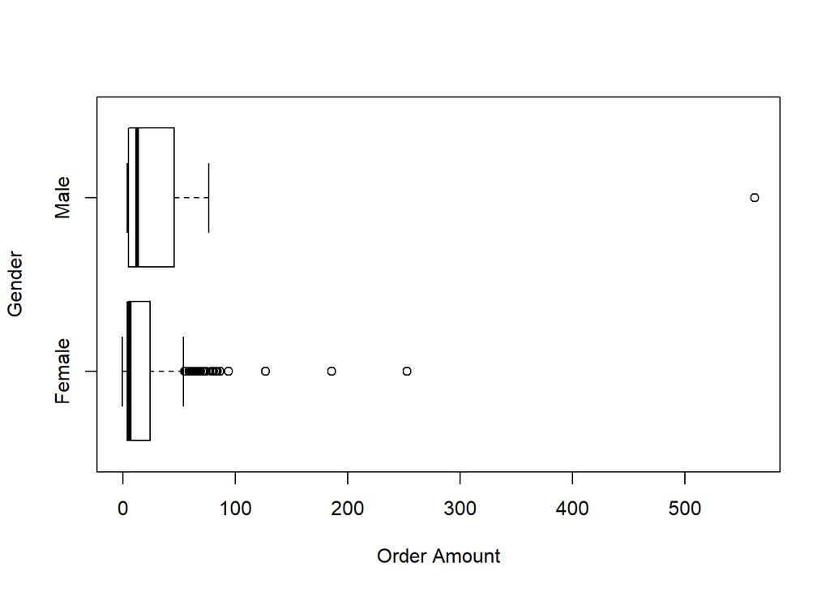

Of course, this graph can be misleading, assuming that the male customer spending more than $500 skews the distribution but the information is nice anyways.

Another valuable information is the location of the customer.

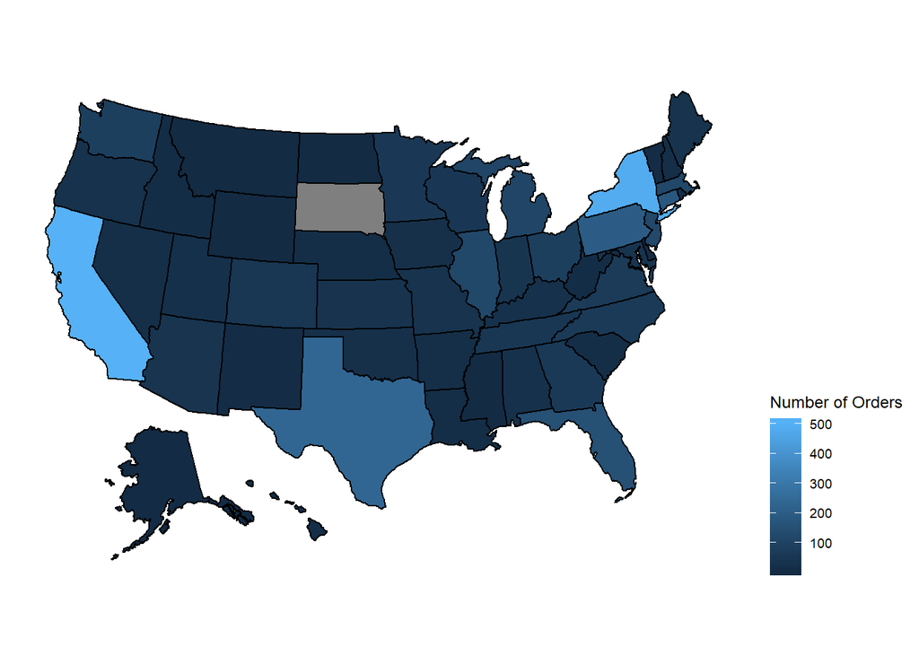

Besides the fact, that the clickstream data and the order data cover different time ranges we compared both datasets. Therefore, we calculate the number of clicks per product from the clickstream dataset and the number of purchases from the order dataset. We compared the distribution of both via a Lorenz curve. Although the result might be compromised by the time gap the Lorenz curve still shows interesting insights about the distribution of clicks and purchases per product.

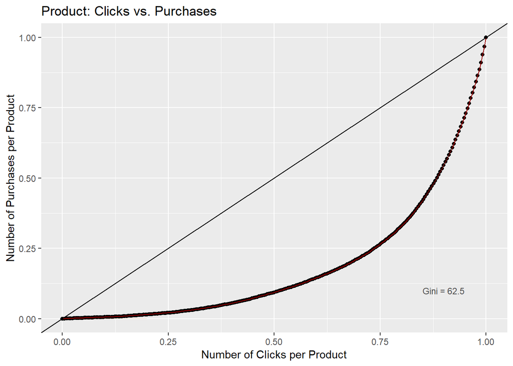

The curve illustrates, that the distribution among clicks and purchases are uneven. A handful of products revive most of the clicks but account only a small order amount. On the other hand, products with a high purchase quantity account only small numbers of clicks. It might be, that products, which lead customers to your webshop are not the products these customer purchase.

# 4 Summary Statistics

In order to show important summary statistics, there are tables in the following paragraphs showing the respective top 5 results from the tables. The first dataset to look at is the clickstream dataset.

## 4.1 Clickstream table

|  | Top 1 | Top 2 | Top 3 | Top 4 | Top 5 |
| --- | --- | --- | --- | --- | --- |
| Referrer | www.gazelle.com | www.fashionmall.com | www.asianavenue.com | www.goto.com | www.AsianAvenue.com |
| Number_of_Referrers | 93730 | 6533 | 2218 | 938 | 688 |
| Product | Cellulite Trimming Gel | Body Lotion - Oceanic Minerals | Kit-Firming Cream/Slimming Cream/Shorts | Body Silk | Herbal Foot Balm |
| Clicks_on_Product | 321 | 270 | 254 | 238 | 228 |
| Top_Click_Hours | 2 | 10 | 9 | 11 | 7 |
| Clicks_per_Hour | 13614 | 9777 | 9222 | 9151 | 8902 |
| Top_Click_Days | Saturday | Thursday | Sunday | Tuesday | Wednesday |
| Clicks_per_Day | 27388 | 25311 | 24605 | 22283 | 21896 |

This table shows the clickstream datasets. Together it contains 164364 click observations. We identified the top five refereeing sites which are show above. Most referres are counted for the gazelle.com website with 93730 refers. This is a very clear first place and it also contains most of the clickstream data.  
Among the products, the clicks are a lot more equally distributed. The most favorite product is the Cellulite Trimming Gel with 321 clicks. Compared to the overall number of observations this seems to be very little, but in these clickstream observations all intermediate steps are contained as well, resulting in less actual products being clicked.  
The favorite hour of the day for clicking on this webshop is 2 am. This is an interesting insight, as it might help improve the site to match customers that browse the webshop at night. The other hours are all in the morning, between 7 and 11 am.  
From the days, obviously the weekend is most common with being among the top three. Interestingly the Friday is not one of the top five clicked days.

## 4.2 Session Table

| summary_stats | max | mean | median | min | sd |
| --- | --- | --- | --- | --- | --- |
| Request_count | 1842.00000 | 3.250999 | 1 | 1 | 17.8620117 |
| Session_duration_mins | 84.28333 | 1.249770 | 0 | 0 | 3.6680154 |
| Visited_assortments | 4.00000 | 1.270323 | 1 | 1 | 0.4837795 |
| Visited_products | 154.00000 | 1.321453 | 1 | 1 | 1.9212895 |

The session dataset consists of 50558 session observations. As can be seen in the median for the request count, at least 50 % of the sessions do not consist of more than one observation. Logically, the shortest session duration is zero, as this metric can only be calculated by looking at the first and the last request time. Accordingly, most sessions also do not look at more than one product and at more than one assortment.

## 4.3 Order tables

The first table shows, similar to the clickstream data, the top 5 elements of selected categories.

|  | Top1 | Top2 | Top3 | Top4 | Top5 |
| --- | --- | --- | --- | --- | --- |
| Product_ID | 12883 | 10877 | 12327 | 12567 | 12675 |
| Orders_per_Product_ID | 142 | 120 | 119 | 105 | 94 |
| Product_Name | Cellulite Trimming Gel | Leg Therapy Cream | Toe Separators | Power Toenail Clipper | Sole Survivor Foot Kit |
| Orders_per_Product_Name | 9 | 9 | 7 | 7 | 7 |
| Customer_ID | 30208 | 2240 | 22742 | 538 | 25004 |
| Orders_per_Customer | 30 | 28 | 22 | 19 | 18 |
| Customer__ID | 29244 | 3778 | 28144 | 2240 | 30208 |
| Purchased_Products_per_Customer | 53 | 40 | 33 | 32 | 30 |
| Brand | AME | Silk Reflections | ELT | HOSO | DAN |
| Orders_per_Brand | 822 | 485 | 399 | 361 | 270 |
| Top_Sale_Hours | 16 | 17 | 19 | 14 | 10 |
| Orders_per_Hours | 231 | 225 | 225 | 223 | 214 |
| Top_Sale_Days | Wednesday | Tuesday | Thursday | Friday | Saturday |
| Orders_per_Day | 934 | 614 | 602 | 571 | 292 |

As can be seen in the table, not all products are associated with a product name. For this reason, the top product identifiers are listed to provide this information for later interpretation. Another interesting aspect is that some customers purchase many times. Other customers purchase many items at once. The second aggregation includes all preceding purchases, which means that for example the customer with the identifier 30208 ordered 30 times, but only one item each resulting in the 30 items in the purchased products per customer row.  
The most popular brand is AME by a large margin, followed by Silk Reflections and ELT.  
The top sale hours are, in contrast to the click hours, rather in the afternoon. But as can be seen, all values are close together meaning that the difference between the hours is not that large. Looking at the most popular days for purchasing, the Wednesday is clearly on top. Here, the difference to the clickstreams is clearer, because the weekend comes almost in last place for purchasing.

The following table is based on a subset of the order data, all orders that are marked as a return.

| summary_Return | max | mean | median | min | sd |
| --- | --- | --- | --- | --- | --- |
| Return_Quantity | 3.00 | 1.5714286 | 1 | 1.00 | 0.7867958 |
| Returned_Products | 2.00 | 1.1428571 | 1 | 1.00 | 0.3779645 |
| Used_Promotions | 1.00 | 0.7142857 | 1 | 0.00 | 0.4879500 |
| Discount_Amount | 10.00 | 7.1428571 | 10 | 0.00 | 4.8795004 |
| Discount_from_Sale_Price | 2.12 | 0.3028571 | 0 | 0.00 | 0.8012847 |
| Return_Amount | 44.50 | 23.0514286 | 30 | 3.95 | 16.6189404 |

The table “Summary_Return” is based on 7 return observations. As can be seen, there are not a lot of observations for this category of orders, thus this summary table is a little less meaningful than the others above.  
The following table is based on all orders that have a ordered quantity larger than zero to make the summary statistics for the whole dataset more representative of the actual orders.

| summary_Order | max | mean | median | min | sd |
| --- | --- | --- | --- | --- | --- |
| Order_Quantity | 53.00 | 2.3678460 | 2.00 | 1.0 | 2.7269390 |
| Purchased_Products | 9.00 | 1.3949011 | 1.00 | 1.0 | 0.8280827 |
| Used_Promotions | 1.00 | 0.8397503 | 1.00 | 0.0 | 0.3669330 |
| Discount_Amount | 50.00 | 8.6569823 | 10.00 | 0.0 | 7.3041332 |
| Discount_from_Sale_Price | 37.34 | 0.2050780 | 0.00 | 0.0 | 1.7156709 |
| Order_Amount | 562.35 | 14.0066441 | 5.95 | -0.7 | 26.3904424 |
| Creditcard_Payment_Amount | 562.35 | 21.4663424 | 14.95 | 0.0 | 27.0717254 |

The table “Summary_Order” is based on 1922 order observations. Here can be seen that most people order the product at least twice, as shown by the order quantity median. Most people also use a promotion, which means that promotions have a large impact on purchases. The negative minimum in the row Order Amount looks suspicious. Research in the data revealed that the orders: order-Id 12314 and order-Id 10930 used a special combination of products and the promotion code FRIEND to generate a negative order amount. However, the credit card payment amount indicates that the coups did not succeed. Also, the datasets cannot tell if the negative Order Amount were created willingly or through accident.

# 5 Prediction

## 5.1 Predict on Clickstream

Using the sesssion dataset, the idea is to predict from the session metadata whether a customer is going to buy something at the end of the session. For that, useful features are selected, namely the session duration, the session day, hour and the referrer. Using this as a basic dataset, there is an issure with the session duration. As mentioned earlier, it is not possible to calculate a session duration for sessions with just one request. For that reason, all entries with only one request are filtered.

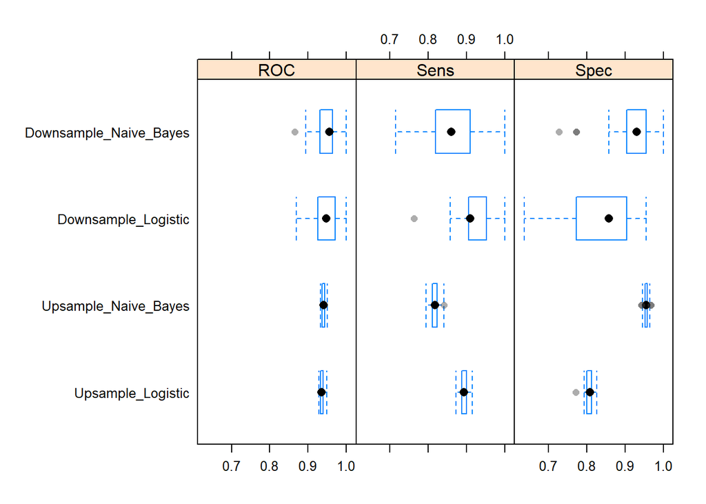

## 5.2 Predict on Orders

To make your company able to improve customer loyalty we build an induction tree model, which separates the “one-time ordering customers” from “more time ordering customers”. The underlaying assumption is that “more time buyers” are more value. We used a tree model since, compared with other models the findings can be communicated low-tech within our company. The rules separating the customers can be looked up at the induction tree graphic. The prediction model and the findings enable your company to target those customers which are more likely place a second order. This leads to a better marketing fund utilization and a stronger customer loyalty.

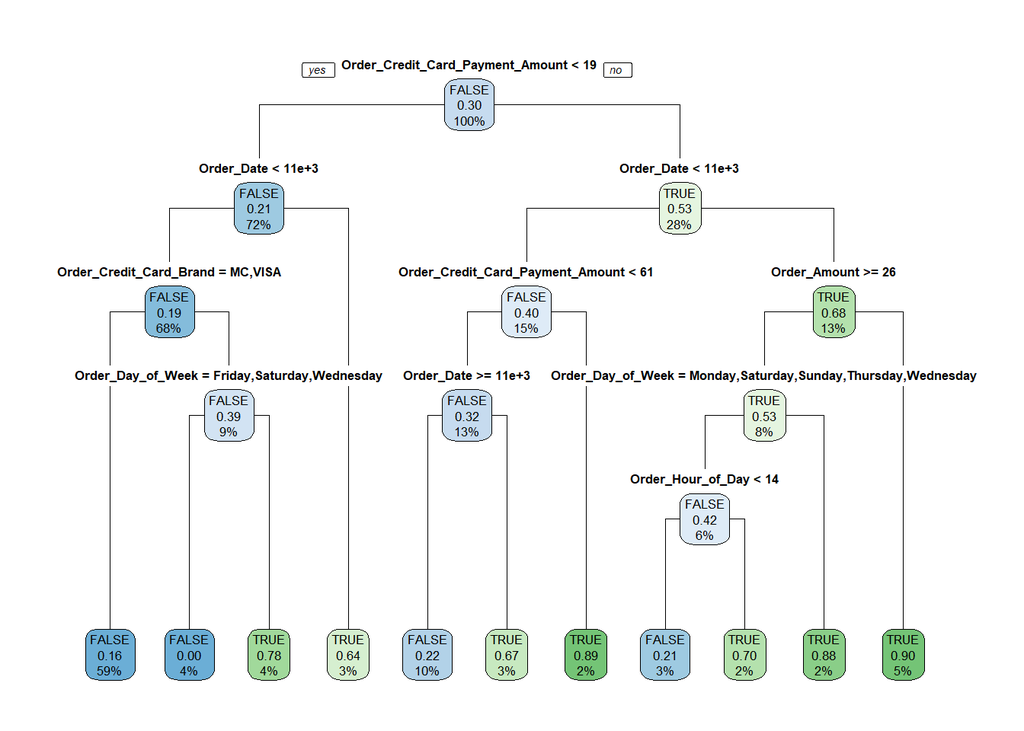

The first tree indicates, that the credit card payment amount is a strong indicator for the prediction more time buyer true or false. The splitting rule, the classification, the probability of classification, and the percentage of entities at are point are listed at each splitting point. A probability under 0.5 means the prediction is one-time buyer and a probability over 0.5 means the model predicts more time buyer. The tree is obviously not suitable for communication within our company due to the complexity. Also, the tree is likely to be overfitted to the training dataset.

| False_probability | True_probability | moretimebuyer | Order_Credit_Card_Payment_Amount |
| --- | --- | --- | --- |
| 0.3000000 | 0.7000000 | TRUE | 63.01 |
| 0.8410042 | 0.1589958 | FALSE | 13.95 |
| 0.2222222 | 0.7777778 | FALSE | 14.45 |
| 0.8410042 | 0.1589958 | FALSE | 13.95 |
| 0.1250000 | 0.8750000 | TRUE | 54.00 |
| 0.7857143 | 0.2142857 | FALSE | 39.95 |

The table above is a sample of the prediction results and the testdata set. The first two columns list the instances probability to be one-time buyer as False probability and more time buyer as TRUE probability. The third and fourth columns list the actual label and the credit card payment amount of each instance.

Table 5.1: Confusion_matrix

| model accuracy |
| --- |
| 0.8025 |

|  | FALSE | TRUE |
| --- | --- | --- |
| FALSE | 253 | 56 |
| TRUE | 24 | 72 |

In order to evaluate the model, we use the overall accuracy and a confusion matrix. Despite the complexity the first tree is doing a fair prediction on the testdata set, but the model is far better in identifying one-time buyer than more time buyer. The likely cause for this is the small amount of more time buyer observations in the training set. Still the model is doing a far better job than random guessing, where the accuracy would be around 50%.

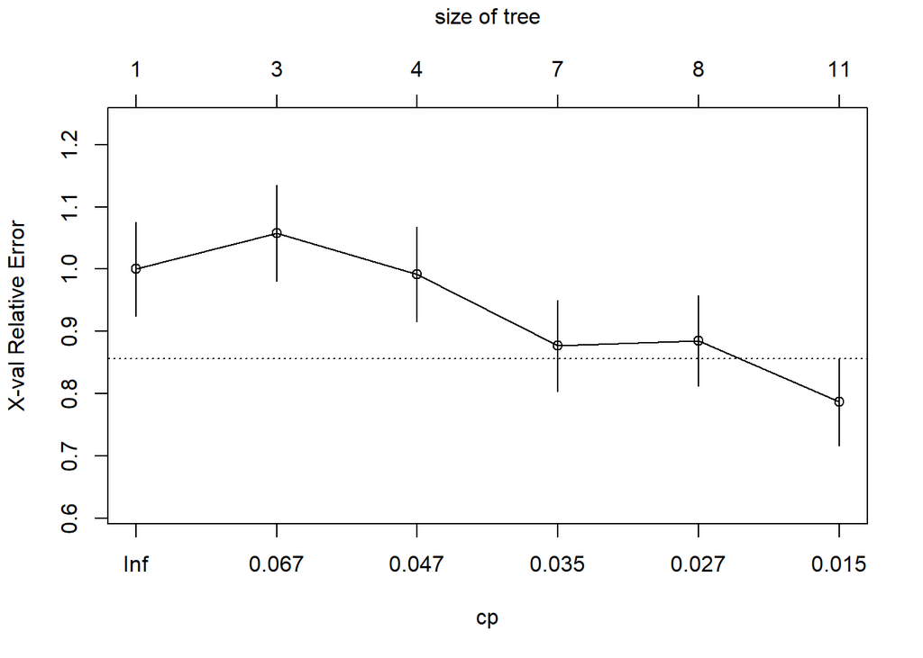

| CP | nsplit | rel error | xerror | xstd |
| --- | --- | --- | --- | --- |
| 0.0778689 | 0 | 1.0000000 | 1.0000000 | 0.0756404 |
| 0.0573770 | 2 | 0.8442623 | 1.0573770 | 0.0768087 |
| 0.0382514 | 3 | 0.7868852 | 0.9918033 | 0.0754632 |
| 0.0327869 | 6 | 0.6721311 | 0.8770492 | 0.0726975 |
| 0.0218579 | 7 | 0.6393443 | 0.8852459 | 0.0729134 |
| 0.0100000 | 10 | 0.5737705 | 0.7868852 | 0.0701230 |

In order to avoid overfitting, the cross-validation error from the first tree is used to build a second tree. The graph shows the cross-validation error vs. the model complexity. The cross-validation error is used to find the optimal complexity and this complexity is used to prune the second tree.

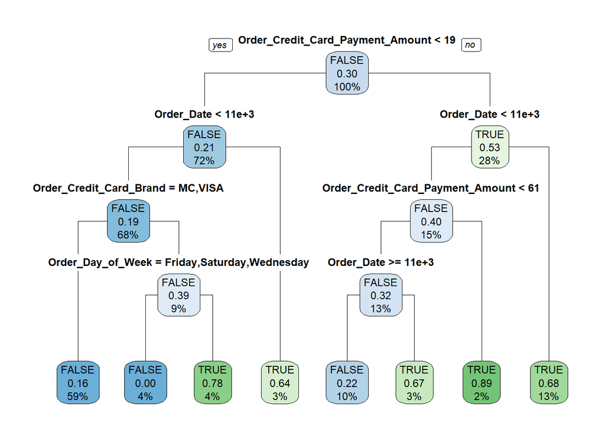

The second tree is less complex then the first one. Like before the splitting rule, the classification, the probability of classification, and the percentage of entities at a point are shown for each splitting point. Also, a probability under 0.5 means the prediction is one-time buyer and a probability over 0.5 means the model predicts more time buyer. The main benefit of the second tree is the simplification, which makes it easier to communicate findings and to use them as a competitive advantage in sale campaigns and in marketing campaigns.

| model accuracy |
| --- |
| 0.7827 |

|  | FALSE | TRUE |
| --- | --- | --- |
| FALSE | 239 | 50 |
| TRUE | 38 | 78 |

The performance of the second tree is slightly worse than the performance of the first tree. The performance is listed as overall accuracy and as a confusion matrix above. Despise that the prediction is still better than random guessing. And since the main aim of the second model is simplified communication of the findings the small reduction in performance is a fair tradeoff. Overall the second tree combinates a good prediction and a less complex model.

| False_probability | True_probability | moretimebuyer | Order_Credit_Card_Payment_Amount | Order_Day_of_Week | Order_Credit_Card_Brand |
| --- | --- | --- | --- | --- | --- |
| 0.1250000 | 0.8750000 | TRUE | 54.00 | Tuesday | VISA |
| 0.0952381 | 0.9047619 | TRUE | 20.95 | Friday | VISA |
| 0.0952381 | 0.9047619 | TRUE | 19.95 | Tuesday | AMEX |
| 0.1250000 | 0.8750000 | TRUE | 31.95 | Friday | AMEX |
| 0.0952381 | 0.9047619 | TRUE | NA | Wednesday | VISA |
| 0.0952381 | 0.9047619 | TRUE | NA | Wednesday | NA |
| 0.0952381 | 0.9047619 | TRUE | 42.61 | Friday | NA |
| 0.1250000 | 0.8750000 | TRUE | 45.62 | Tuesday | VISA |
| 0.1250000 | 0.8750000 | TRUE | 42.74 | Tuesday | MC |
| 0.0952381 | 0.9047619 | TRUE | 20.26 | Friday | NA |
| 0.1111111 | 0.8888889 | TRUE | 62.44 | Sunday | NA |
| 0.0952381 | 0.9047619 | TRUE | NA | Wednesday | NA |
| 0.1250000 | 0.8750000 | TRUE | 20.60 | Tuesday | MC |
| 0.1250000 | 0.8750000 | TRUE | 112.00 | Friday | NA |
| 0.0952381 | 0.9047619 | FALSE | 23.94 | Wednesday | MC |
| 0.1250000 | 0.8750000 | FALSE | 43.00 | Friday | AMEX |
| 0.0952381 | 0.9047619 | TRUE | 33.35 | Friday | NA |
| 0.0952381 | 0.9047619 | TRUE | 19.95 | Tuesday | AMEX |
| 0.0952381 | 0.9047619 | TRUE | NA | Wednesday | NA |
| 0.0952381 | 0.9047619 | TRUE | 21.55 | Wednesday | MC |
| 0.0952381 | 0.9047619 | TRUE | 26.15 | Thursday | NA |
| 0.0952381 | 0.9047619 | FALSE | NA | Friday | MC |
| 0.0952381 | 0.9047619 | TRUE | 19.95 | Tuesday | AMEX |
| 0.1111111 | 0.8888889 | TRUE | 210.99 | Thursday | NA |
| 0.1111111 | 0.8888889 | TRUE | 210.99 | Thursday | NA |
| 0.1111111 | 0.8888889 | TRUE | 87.78 | Sunday | NA |
| 0.1111111 | 0.8888889 | TRUE | 136.95 | Tuesday | NA |
| 0.0952381 | 0.9047619 | TRUE | 19.36 | Friday | NA |
| 0.0952381 | 0.9047619 | TRUE | 62.07 | Thursday | NA |
| 0.1250000 | 0.8750000 | TRUE | NA | Tuesday | VISA |
| 0.1111111 | 0.8888889 | TRUE | 62.44 | Wednesday | NA |
| 0.1111111 | 0.8888889 | FALSE | 76.20 | Thursday | VISA |
| 0.1250000 | 0.8750000 | FALSE | 57.00 | Friday | VISA |
| 0.1250000 | 0.8750000 | TRUE | 97.99 | Friday | NA |
| 0.0952381 | 0.9047619 | TRUE | 63.01 | Thursday | NA |
| 0.1111111 | 0.8888889 | FALSE | 95.50 | Wednesday | AMEX |
| 0.0952381 | 0.9047619 | TRUE | 21.93 | Thursday | VISA |
| 0.0952381 | 0.9047619 | TRUE | 22.45 | Friday | NA |
| 0.1250000 | 0.8750000 | TRUE | 97.99 | Friday | NA |
| 0.0952381 | 0.9047619 | FALSE | 31.01 | Wednesday | VISA |

One way to mine the result of the prediction tree would be to rank the instances by the “True probability” and target the instances over a certain threshold. Like in the table above with a threshold of 0.8 True_probability. Another approach is to train customer support personnel, sales personnel, and marketing personnel with the second induction tree model to give them a better understanding of profitable customers. This will enable our employees to target these customers directly. Both suggested methods can be applied by itself or together.

## 5.3 Experiment

Recommender Systems

For the websites recommender systems, there are different options. In an experiment, three different recommender systems were tested. First a random recommendation system as baseline comparison for the experiment, second a ranking based recommender system and third a profit-oriented recommender system. The data consisted of 146 observations for the profit-oriented system, 149 for the random one and 154 observations for the ranking based system.

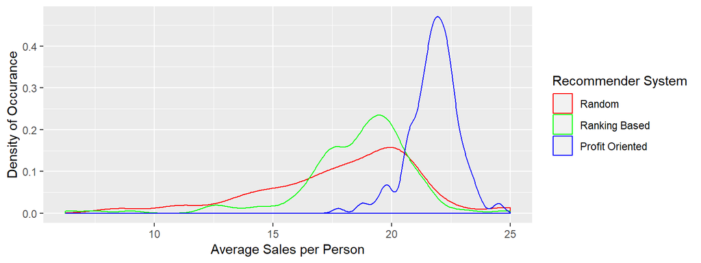

# 6 Conclusion

Though the prediction we discovered that one strong indicator separating one-time buyers from the more time buyers is the Credit Card Payment Amount. This discovered rule and the other rules are shown in the prediction tree. The rules can be used to gain a competitive advantage. One way to do so is to use the prediction model on order of new customers. Another is to train your employees with the tree so they can target customers, which are more likely to do another order. The accuracy of the tree can be improved with additional observations of more time buyers first orders. The evaluation of the Recommender Systems shows that the profit orientated recommender system performed best out of the three Random, Ranking and Profit orientated.